# DATA624 - Homework 3

Esteban Aramayo

2022-06-17

```r
library(fpp2)
library(forecast)
```

# Week 3: ARIMA Models [13-Jun 19-Jun]

## Chapter 8 ARIMA Models (Forecasting: Principle and Practice HA)

### Exercise 8.11.1 (aka 8.1)

Figure 8.31 shows the ACFs for 36 random numbers, 360 random numbers and 1,000 random numbers.

#### 8.11.1.a

Explain the differences among these figures. Do they all indicate that the data are white noise?

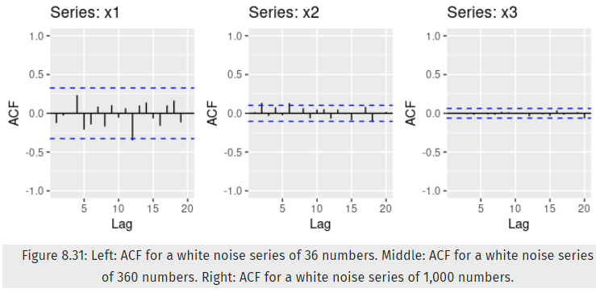

#### 8.11.1.b

Why are the critical values at different distances from the mean of zero? Why are the autocorrelations different in each figure when they each refer to white noise?

### Exercise 8.11.2 (aka 8.2)

A classic example of a non-stationary series is the daily closing IBM stock price series (data set ibmclose). Use R to plot the daily closing prices for IBM stock and the ACF and PACF. Explain how each plot shows that the series is non-stationary and should be differenced.

### Exercise 8.11.6 (aka 8.6)

Use R to simulate and plot some data from simple ARIMA models.

### Exercise 8.11.6.a

Use the following R code to generate data from an AR(1) model with  
$\phi_1 = 0.6$ and $\sigma^2 = 1$. The process starts with $y_1 = 0$.

```r
y <- ts(numeric(100))
e <- rnorm(100)
for(i in 2:100)
  y[i] <- 0.6*y[i-1] + e[i]
```

### Exercise 8.11.6.b

Produce a time plot for the series. How does the plot change as you change $\phi = 1$?

The produced time plots for multiple series based on different values of phi_1 reveal that

- As the values of phi_1 increase, the amplitude and period of the spikes increase.

Plot the data in the time series $y$.

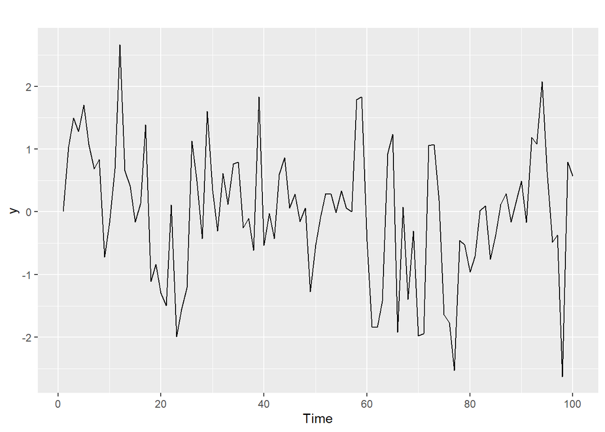

```r
autoplot(y)
```

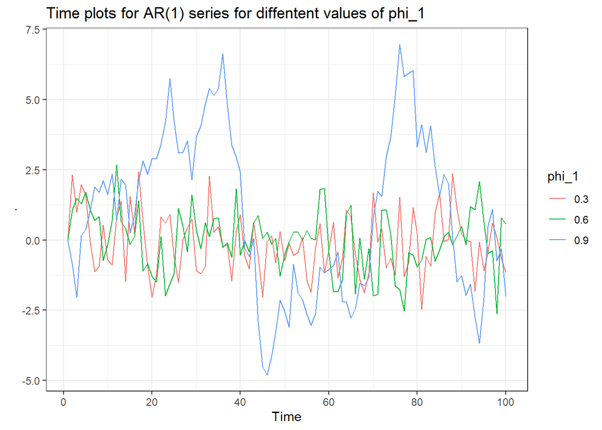

```r
# define function that generates AR(1) series based on a phi_1 parameter
generateAR1Series <- function (phi_1) {

  y <- ts(numeric(100))
  e <- rnorm(100)
  for(i in 2:100)
    y[i] <- phi_1 * y[i-1] + e[i]

  return(y)
}

# Produce a time plots for multiple series based on different values of phi_1
generateAR1Series(0.3) %>%
  autoplot(series = "0.3") +
  autolayer(y, series = "0.6") +
  autolayer(generateAR1Series(0.9), series = "0.9") +
  guides(color = guide_legend(title = "phi_1")) +
  ggtitle("Time plots for AR(1) series for diffentent values of phi_1") +
  theme_bw()
```

### Exercise 8.11.6.c

Write your own code to generate data from an MA(1) model with $\theta_1 = 0.6$ and $\sigma^2 = 1$.

```r
# define function that generates MA(1) series based on a theta_1 parameter
generateMA1Series <- function (theta_1) {

  y <- ts(numeric(100))
  e <- rnorm(100)
  for(i in 2:100)
    y[i] <- theta_1 * e[i-1] + e[i]

  return(y)
}
```

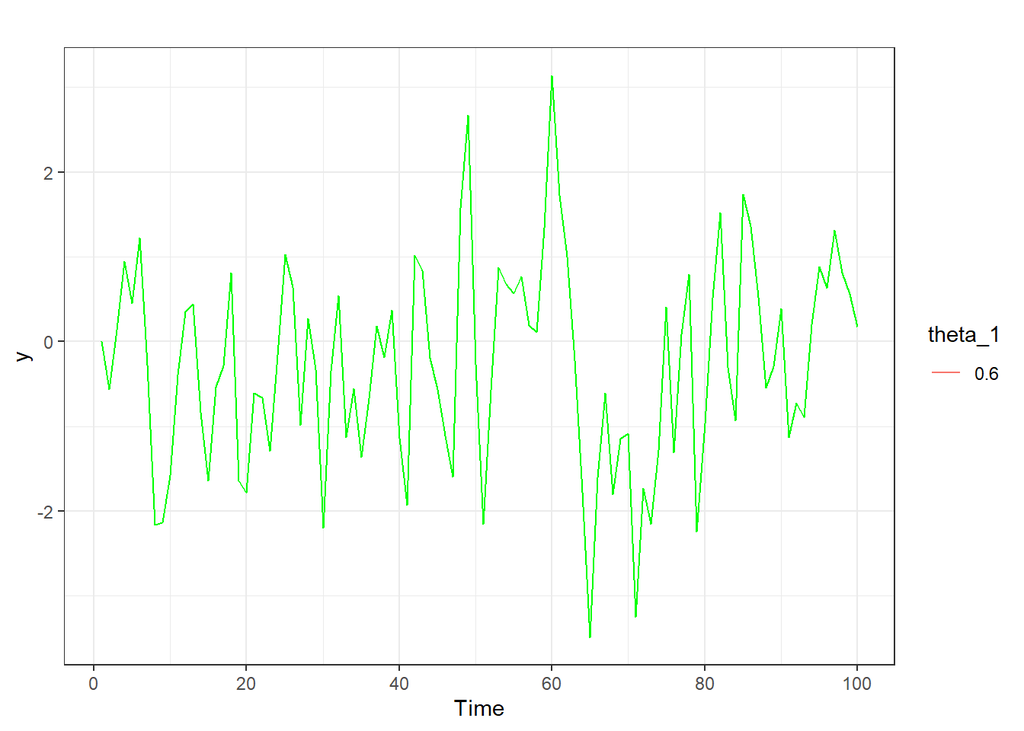

```r
y <- generateMA1Series(theta_1 = 0.6)

autoplot(y, series = "0.6") +
  geom_line(color = "green") +
  guides(color = guide_legend(title = "theta_1")) +
  theme_bw()
```

### Exercise 8.11.6.d

Produce a time plot for the series. How does the plot change as you change $\theta_1$?

The produced time plots for multiple series based on different values of theta_1 reveal that

- As the values of theta_1 increase, the amplitude of the spikes increase.

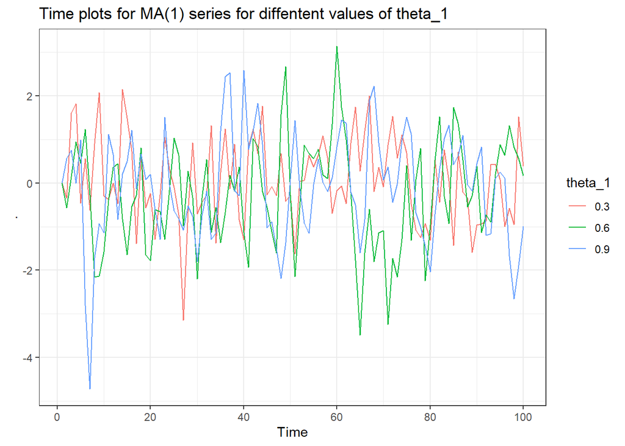

```r
# Produce a time plots for multiple series based on different values of theta_1
generateMA1Series(0.3) %>%
  autoplot(series = "0.3") +
  autolayer(y, series = "0.6") +
  autolayer(generateMA1Series(0.9), series = "0.9") +
  guides(color = guide_legend(title = "theta_1")) +
  ggtitle("Time plots for MA(1) series for diffentent values of theta_1") +
  theme_bw()
```

### Exercise 8.11.6.e

Generate data from an ARMA(1,1) model with $\phi_1 = 0.6$, $\theta_1 = 0.6$, and $\sigma^2 = 1$

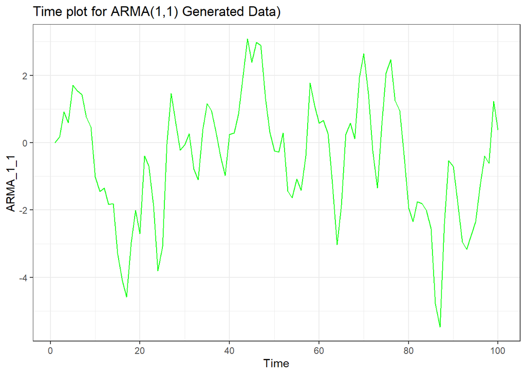

```r
ARMA_1_1 <- ts(numeric(100))

e <- rnorm(100, sd = 1)

for(i in 2:100)
  ARMA_1_1[i] <- 0.6 * ARMA_1_1[i-1] + 0.6 * e[i-1] + e[i]


autoplot(ARMA_1_1) +
  geom_line(color = "green") +
  theme_bw() +
  ggtitle("Time plot for ARMA(1,1) Generated Data)")
```

### Exercise 8.11.6.f

Generate data from an AR(2) model with $\phi_1 = -0.8$, $\phi_2 = 0.3$, and $\sigma^2 = 1$. (Note that these parameters will give a non-stationary series.)

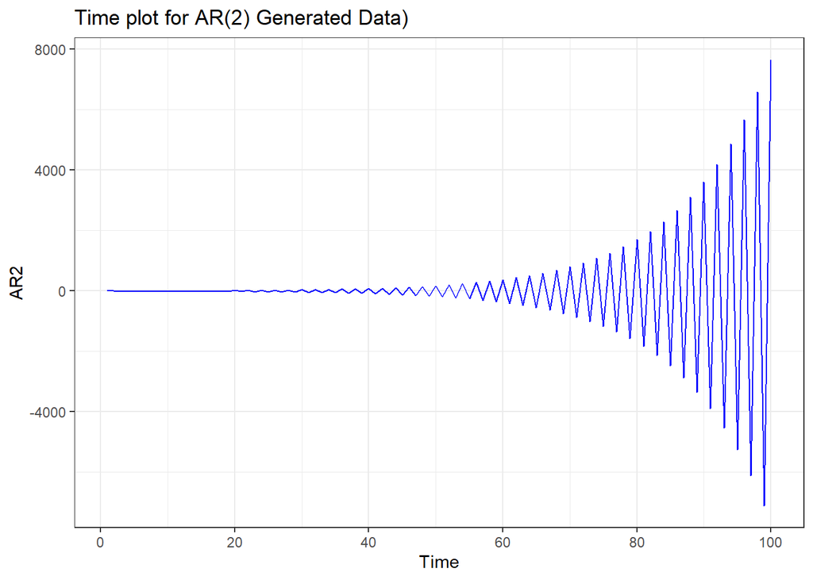

```r
AR2 <- ts(numeric(100))

e <- rnorm(100, sd = 1)

for(i in 3:100)
  AR2[i] <- -0.8 * AR2[i-1] + 0.3 * AR2[i-2] + e[i]


autoplot(AR2) +
  geom_line(color = "blue") +
  theme_bw() +
  ggtitle("Time plot for AR(2) Generated Data)")
```

### Exercise 8.11.6.g

Graph the latter two series and compare them.

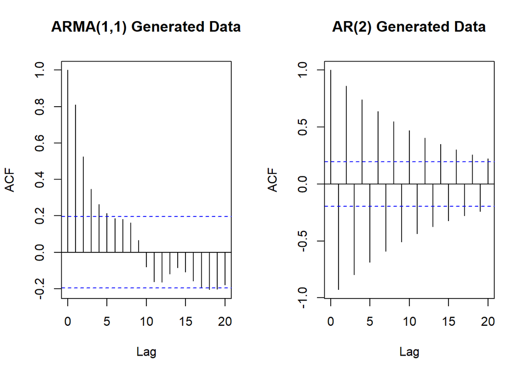

```r
par(mfrow = c(1,2))
acf(ARMA_1_1, main ='ARMA(1,1) Generated Data')
acf(AR2, main ='AR(2) Generated Data')
```

### Exercise 8.11.8 (aka 8.8)

Consider austa, the total international visitors to Australia (in millions) for the period 1980-2015.

```r
data(austa)
```

#### Exercise 8.11.8.a

Use auto.arima() to find an appropriate ARIMA model. What model was selected. Check that the residuals look like white noise. Plot forecasts for the next 10 periods.

- The $auto.arima()$ function selected the **ARIMA(0,1,1) with drift** model.
- The residuals from the selected model look like white noise because appear to be normal and not obviously significant.
- The forecasts plot for the next 10 periods shows a steady upwards positive trend.

```r
# Fit best ARIMA model to the austa time series
auto_arima_austa <-forecast::auto.arima(austa)

# Show the results summary of the fitted model
summary(auto_arima_austa)
```

```
#> Series: austa
#> ARIMA(0,1,1) with drift
#>
#> Coefficients:
#>          ma1   drift
#>       0.3006  0.1735
#> s.e.  0.1647  0.0390
#>
#> sigma^2 = 0.03376:  log likelihood = 10.62
#> AIC=-15.24   AICc=-14.46   BIC=-10.57
#>
#> Training set error measures:
#>                        ME      RMSE       MAE       MPE     MAPE      MASE
#> Training set 0.0008313383 0.1759116 0.1520309 -1.069983 5.513269 0.7461559
#>                      ACF1
#> Training set -0.000571993
```

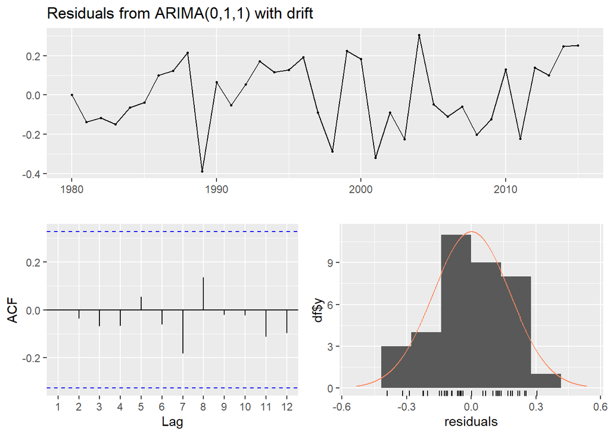

```
#>
#>  Ljung-Box test
#>
#> data:  Residuals from ARIMA(0,1,1) with drift
#> Q* = 2.297, df = 5, p-value = 0.8067
#>
#> Model df: 2.   Total lags used: 7
```

```r
# Check that residuals from the time series model look like white noise
# and produce a time plot of the residuals
checkresiduals(auto_arima_austa, plot = TRUE)
```

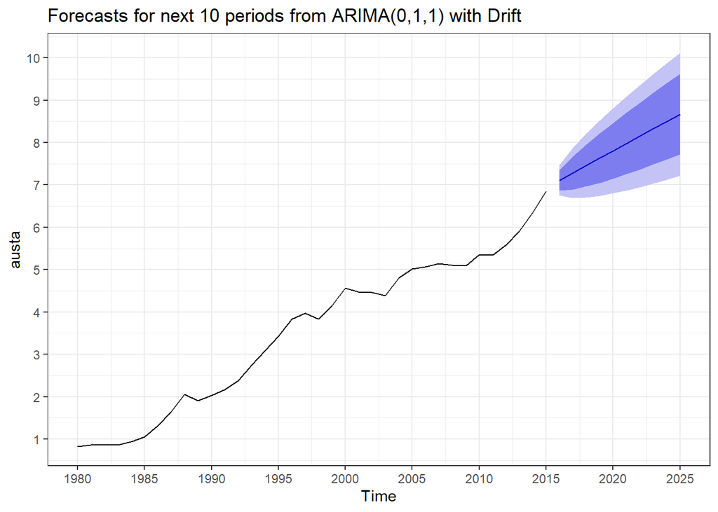

```r
# Forecasts for the next 10 periods
fc_auto_arima_austa <- forecast(auto_arima_austa, h = 10)

# Plot forecasts for the next 10 periods
autoplot(fc_auto_arima_austa) +
  ggtitle("Forecasts for next 10 periods from ARIMA(0,1,1) with Drift") +
  theme_bw() +
  scale_x_continuous(breaks = seq(from = 1980, to = 2030, by = 5)) +
  scale_y_continuous(breaks = seq(from = 0, to = 11, by = 1))
```

#### Exercise 8.11.8.b

Plot forecasts from an ARIMA(0,1,1) model with no drift and compare these to part a. Remove the MA term and plot again.

- Compared to the forecast plot in part (a), the forecasts plot from an ARIMA(0,1,1) model with no drift, no longer longer shows an upward trend. Instead, it shows a constant flat line at 7.0.
- Compared to the forecast plot in part (a), the forecasts plot from an ARIMA(0,1,0) model with no drift and with the MA term removed, also shows a constant flat line but shifted 0.1735 units below 7.0. Additionally, the confidence intervals (80 and 95) seem to have narrowed slightly.

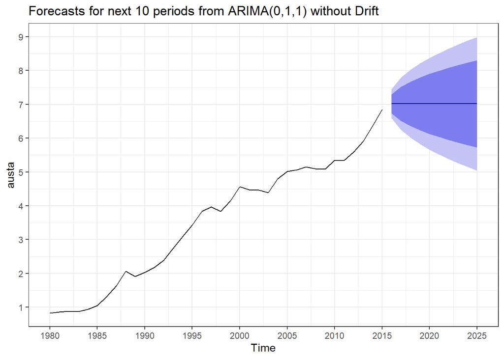

```r
# Fit an ARIMA(0,1,1) model to the austa time series
# by default the include.drift parameter is set to FALSE
arima_011_nd_austa <- forecast::Arima(austa, order = c(0, 1, 1), include.drift = FALSE)

# Forecasts for the next 10 periods
fc_arima_011_nd_austa <- forecast(arima_011_nd_austa, h = 10)

# Plot forecasts for the next 10 periods
autoplot(fc_arima_011_nd_austa) +
  ggtitle("Forecasts for next 10 periods from ARIMA(0,1,1) without Drift") +
  theme_bw() +
  scale_x_continuous(breaks = seq(from = 1980, to = 2030, by = 5)) +
  scale_y_continuous(breaks = seq(from = 0, to = 11, by = 1))
```

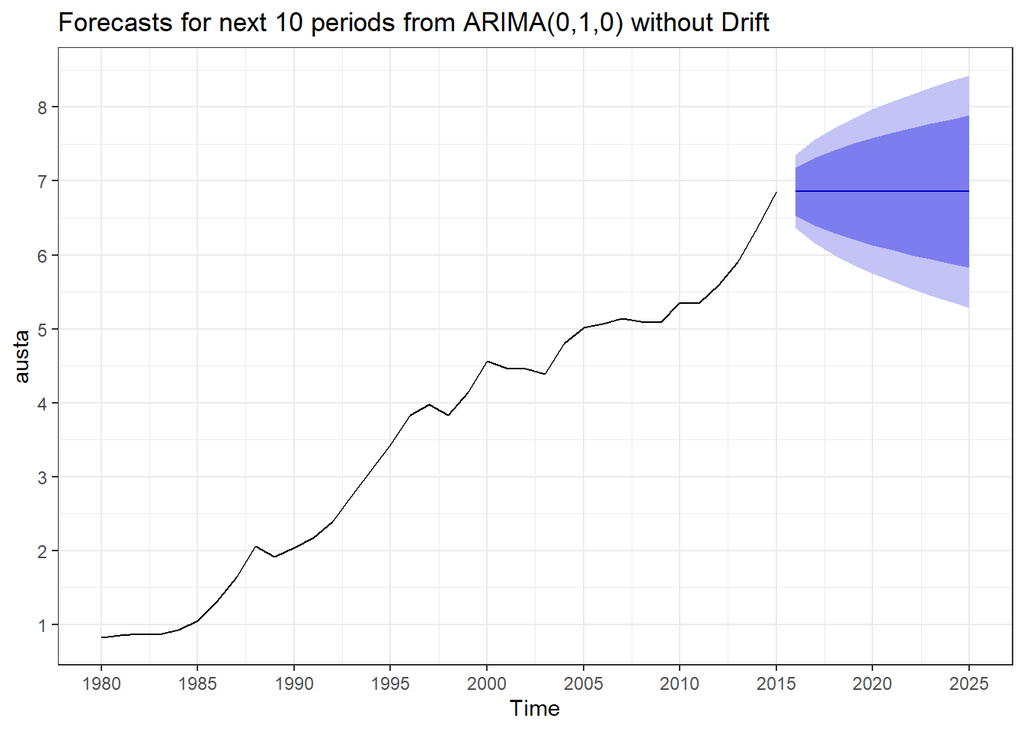

```r
# Fit an ARIMA(0,1,0) model (MA term removed) to the austa time series
# by default the include.drift parameter is set to FALSE
arima_010_nd_austa <- forecast::Arima(austa, order = c(0, 1, 0), include.drift = FALSE)

# Forecasts for the next 10 periods
fc_arima_010_nd_austa <- forecast(arima_010_nd_austa, h = 10)

# Plot forecasts for the next 10 periods
autoplot(fc_arima_010_nd_austa) +
  ggtitle("Forecasts for next 10 periods from ARIMA(0,1,0) without Drift") +
  theme_bw() +
  scale_x_continuous(breaks = seq(from = 1980, to = 2030, by = 5)) +
  scale_y_continuous(breaks = seq(from = 0, to = 11, by = 1))
```

#### Exercise 8.11.8.c

Plot forecasts from an ARIMA(2,1,3) model with drift. Remove the constant and see what happens.

- The first forecast plot shows a slowly upward trend (almost concave down shape)
- The second forecast plot shows a faster upward trend (almost linear shape)
- The confidence intervals for the second one are wider.

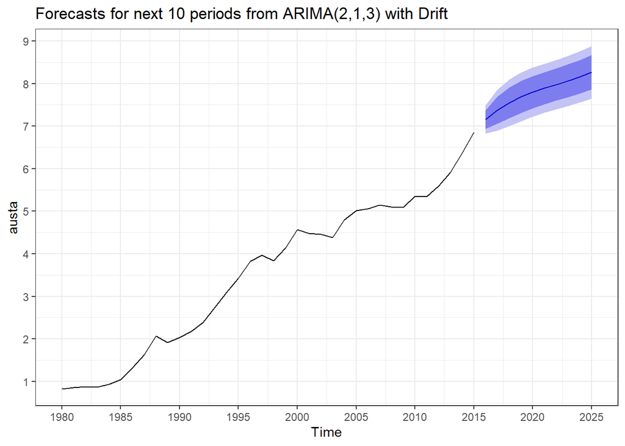

```r
# Fit an ARIMA(2,1,3) model with drift to the austa time series
arima_213_wd_austa <- forecast::Arima(austa, order = c(2,1,3), include.drift = TRUE)

# Forecasts for the next 10 periods
fc_arima_213_wd_austa <- forecast(arima_213_wd_austa, h = 10)

# Plot forecasts for the next 10 periods
autoplot(fc_arima_213_wd_austa) +
  ggtitle("Forecasts for next 10 periods from ARIMA(2,1,3) with Drift") +
  theme_bw() +
  scale_x_continuous(breaks = seq(from = 1980, to = 2030, by = 5)) +
  scale_y_continuous(breaks = seq(from = 0, to = 11, by = 1))
```

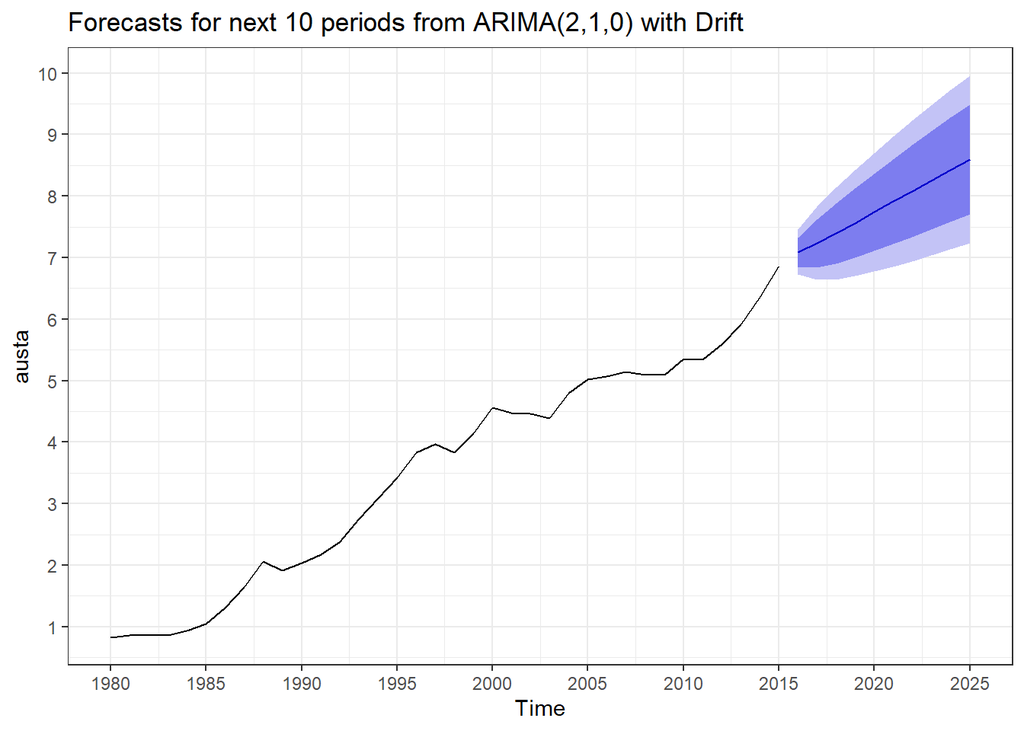

```r
# Fit an ARIMA(2,1,0) model (constant removed) with drift to the austa time series
arima_210_wd_austa <- forecast::Arima(austa, order = c(2,1,0), include.drift = TRUE)

# Forecasts for the next 10 periods
fc_arima_210_wd_austa <- forecast(arima_210_wd_austa, h = 10)

# Plot forecasts for the next 10 periods
autoplot(fc_arima_210_wd_austa) +
  ggtitle("Forecasts for next 10 periods from ARIMA(2,1,0) with Drift") +
  theme_bw() +
  scale_x_continuous(breaks = seq(from = 1980, to = 2030, by = 5)) +
  scale_y_continuous(breaks = seq(from = 0, to = 11, by = 1))
```

#### Exercise 8.11.8.d

Plot forecasts from an ARIMA(0,0,1) model with a constant. Remove the MA term and plot again.

When comparing the forecast plots of ARIMA(0,0,1) model with that of the ARIMA(0,0,0) model, we see that

- The first one shows an immediate trend drop to 5.0 followed by asharp linear downwards trend for the first period, then followed by a flat line trend.
- The second one shows an immediate trend drop to 3.5 followed by a flat line trend.
- The confidence intervals on the second one are wider.

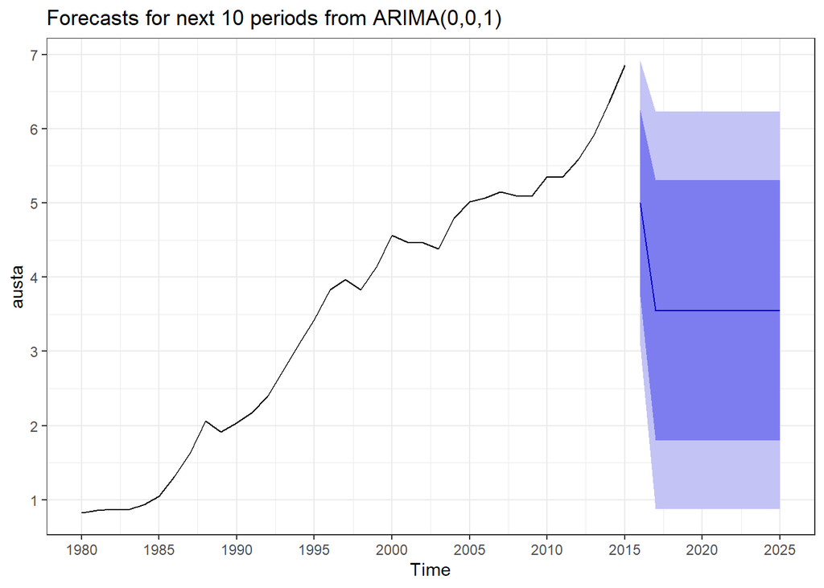

```r
# Fit an ARIMA(0,0,1) model to the austa time series
arima_001_nd_austa <- forecast::Arima(austa, order = c(0,0,1), include.drift = FALSE)

# Forecasts for the next 10 periods
fc_arima_001_nd_austa <- forecast(arima_001_nd_austa, h = 10)

# Plot forecasts for the next 10 periods
autoplot(fc_arima_001_nd_austa) +
  ggtitle("Forecasts for next 10 periods from ARIMA(0,0,1)") +
  theme_bw() +
  scale_x_continuous(breaks = seq(from = 1980, to = 2030, by = 5)) +
  scale_y_continuous(breaks = seq(from = 0, to = 11, by = 1))
```

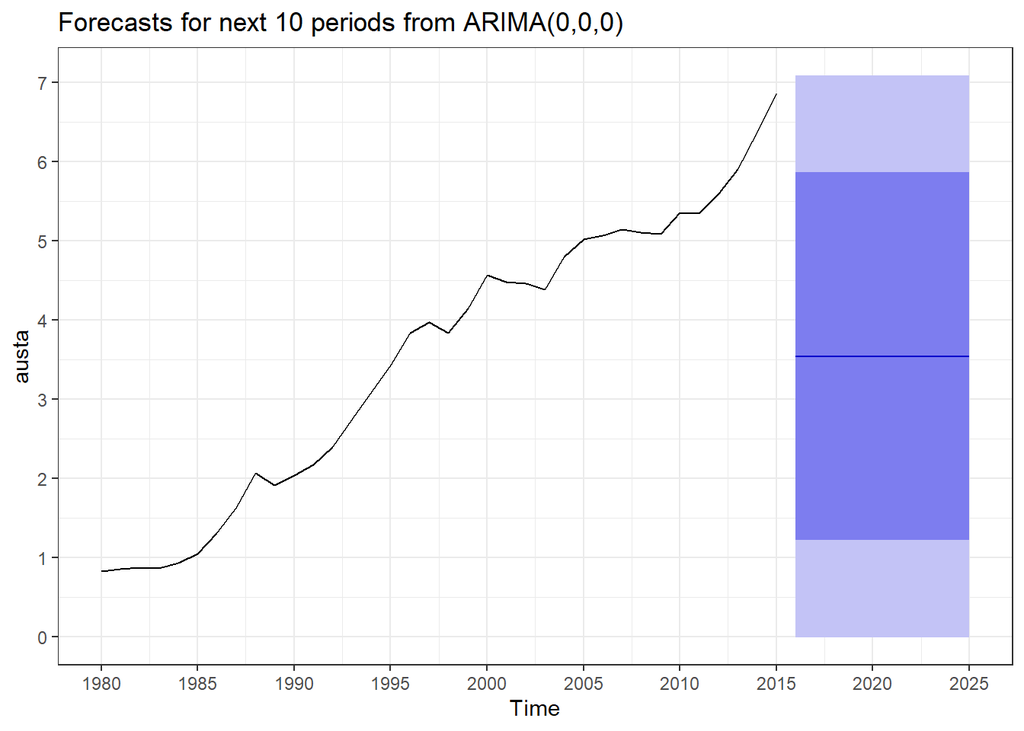

```r
# Fit an ARIMA(0,0,0) model (MA term removed) to the austa time series
arima_000_nd_austa <- forecast::Arima(austa, order = c(0,0,0), include.drift = FALSE)

# Forecasts for the next 10 periods
fc_arima_000_nd_austa <- forecast(arima_000_nd_austa, h = 10)

# Plot forecasts for the next 10 periods
autoplot(fc_arima_000_nd_austa) +
  ggtitle("Forecasts for next 10 periods from ARIMA(0,0,0)") +
  theme_bw() +
  scale_x_continuous(breaks = seq(from = 1980, to = 2030, by = 5)) +
  scale_y_continuous(breaks = seq(from = 0, to = 11, by = 1))
```

#### Exercise 8.11.8.e

Plot forecasts from an ARIMA(0,2,1) model with no constant.

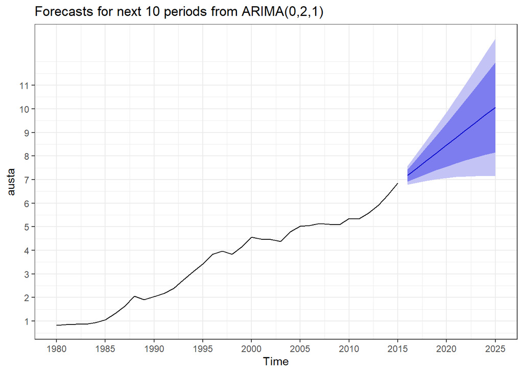

```r
# Fit an ARIMA(0,2,1) model to the austa time series
arima_021_nd_austa <- forecast::Arima(austa, order = c(0,2,1), include.drift = FALSE)

# Forecasts for the next 10 periods
fc_arima_021_nd_austa <- forecast(arima_021_nd_austa, h = 10)

# Plot forecasts for the next 10 periods
autoplot(fc_arima_021_nd_austa) +
  ggtitle("Forecasts for next 10 periods from ARIMA(0,2,1)") +
  theme_bw() +
  scale_x_continuous(breaks = seq(from = 1980, to = 2030, by = 5)) +
  scale_y_continuous(breaks = seq(from = 0, to = 11, by = 1))
```